# Linear Regression Models with Categorical Predictors

**Step 2**: Reporting the linear model

```r
summary(plant.lm)
```

```
| Call:
| lm(formula = weight ~ group, data = plant)
| Residuals:
|     Min      1Q  Median      3Q     Max
| -1.0710 -0.4180 -0.0060  0.2627  1.3690
| Coefficients:
|             Estimate Std. Error t value Pr(>|t|)
| (Intercept)   5.0320     0.1971  25.527   <2e-16 ***
| grouptrt1    -0.3710     0.2788  -1.331   0.1944
| grouptrt2     0.4940     0.2788   1.772   0.0877 .
| ---
| Signif. codes:  0 '***' 0.001 '**' 0.01 '*' 0.05 '.' 0.1 ' ' 1
| Residual standard error: 0.6234 on 27 degrees of freedom
| Multiple R-squared:  0.2641,  Adjusted R-squared:  0.2096
| F-statistic: 4.846 on 2 and 27 DF,  p-value: 0.01591
```

**Interpretation of the output**

Next, we extract the one-way ANOVA table directly from the above linear regression model.

```r
# extract ANOVA table directly from linear regression model
anova(plant.lm)
```

```
| Analysis of Variance Table
| Response: weight
|           Df  Sum Sq Mean Sq F value  Pr(>F)
| group      2  3.7663  1.8832  4.8461 0.01591 *
| Residuals 27 10.4921  0.3886
| ---
| Signif. codes:  0 '***' 0.001 '**' 0.01 '*' 0.05 '.' 0.1 ' ' 1
```

The F-test from the one-way ANOVA table above is identical to the one reported in the previous regression model. We can also generate the same one-way ANOVA table using R’s built-in function`aov()`

The coefficients associated with dummy variables in the regression output represent the difference between the mean of the underlying category and that of the baseline category. That is, $\hat{\beta}_1 = \hat{\mu}_{\text{trt1}} - \hat{\mu}_{\text{ctr}} = -0.3710$ and $\hat{\beta}_2 = \hat{\mu}_{\text{trt2}} - \hat{\mu}_{\text{ctr}} =0.4940$. This information is given in Tukey’s HSD (see the output of `TukeyHSD()`)

```r
plant.aov <- aov(weight ~ group, data = plant)
TukeyHSD(plant.aov)
```

```
|   Tukey multiple comparisons of means
|     95% family-wise confidence level
| Fit: aov(formula = weight ~ group, data = plant)
| $group
|             diff        lwr       upr     p adj
| trt1-ctrl -0.371 -1.0622161 0.3202161 0.3908711
| trt2-ctrl  0.494 -0.1972161 1.1852161 0.1979960
| trt2-trt1  0.865  0.1737839 1.5562161 0.0120064
```

The first two estimated differences (`trt1 - ctr` and `trt2 - ctr`) correspond to the regression coefficients of the dummy variables in the previous model. The p-values reported in the regression model are unadjusted (based on individual tests), whereas Tukey’s HSD is a group test, and its corresponding p-values are adjusted to control the overall Type I error rate (i.e., to prevent inflation of the false positive rate).

**Remarks:**

- The linear regression model used to perform one-way ANOVA has **multiple dummy predictor variables** in the model formula (although implicitly expressed). In other words, the regression model for the one-way ANOVA is a special **multiple linear Regression** (MLR) model.
- Multiple Linear Regression (MLR) maintains the same assumptions as simple linear regression: independent and identically distributed (i.i.d.) observations, deterministic predictors, linearity between response and predictor, normality of residuals, and homoscedasticity (constant variance). Since MLR involves multiple predictor variables, an additional assumption is the absence of high correlations between predictors. Violation of this assumption is referred to as **multicollinearity** in regression modeling.
- The reason we encode a categorical variable with k categories into (k-1) dummy variables (rather than k) is to avoid multicollinearity issues. For example, suppose we have a categorical variable **Education** with 3 levels: High School (baseline/reference), Bachelor’s, and Master’s. If we create 3 dummy variables:
  - D1 = 1 if High School, 0 otherwise
  - D2 = 1 if Bachelor’s, 0 otherwise
  - D3 = 1 if Master’s, 0 otherwise

  This creates perfect **multicollinearity** because for every observation: D1 + D2 + D3 = 1 (always)!!!

To conclude this section, watch the YouTube video (https://www.youtube.com/watch?v=CMAwKuCw5CM&list=PLfQppi3mzF5nQzSm-RWQnvHFg46GQVK_4&index=4) that focuses on the ANOVA table extracted from the linear regression.

# 4 Multiple Linear Regression Approach to Two-way ANOVA

**This section focuses on linear regression with two categorical variables, each with multiple levels.** We have previously learned about two-way ANOVA based on a replicated Randomized Block Design (RBD), which allows for inference on interaction effects. The linear regression model to be discussed will also include an interaction term.

Since the underlying concept is similar to the one-way ANOVA covered in the previous section, the explicit model formula remains relatively simple. However, the implicit model formula for linear regression with two categorical variables (including an interaction effect) is more complex than that of one-way ANOVA. We will use an example to illustrate some key features of multiple linear regression (MLR) involving only categorical variables with an interaction term.

The dataset recorded the yield of different crops under different fertilizers. The two-way data table is given below.

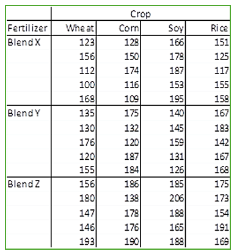

We have used various R commands earlier to convert a two-way data table to an R dataframe for regression modeling. We next use similar code to convert the above table to a dataframe.

```r
## To avoid typing errors, we input the table cell by cell from the data table
crop.data <- data.frame(
  Fertilizer = rep(c("Blend X", "Blend Y", "Blend Z"), each = 20),
  Crop = rep(rep(c("Wheat", "Corn", "Soy", "Rice"), each = 5), times = 3),
  Yield = c(123, 156, 112, 100, 168,   # Blend X - Wheat
            128, 150, 174, 116, 109,   # Blend X - Corn
            166, 178, 187, 133, 195,   # Blend X - Soy
            151, 125, 117, 155, 138,   # Blend X - Rice
            ##
            135, 130, 176, 120, 155,   # Blend Y - Wheat
            175, 132, 120, 187, 184,   # Blend Y - Corn
            140, 145, 159, 131, 126,   # Blend Y - Soy
            167, 188, 142, 167, 168,   # Blend Y - Rice
            ##
            156, 180, 147, 146, 193,   # Blend Z - Wheat
            186, 138, 178, 176, 190,   # Blend Z - Corn
            185, 206, 188, 165, 188,   # Blend Z - Soy
            175, 173, 154, 191, 169)   # Blend Z - Rice
)

# Convert factors to factors (important for modeling)
crop.data$Fertilizer <- as.factor(crop.data$Fertilizer)
crop.data$Crop <- as.factor(crop.data$Crop)
```

Next, we fit a linear regression model with an interaction term and list the terms (dummy variables) in the implicit internal model formula by using two R functions `model.matrix(model.name)` and `colnames(model.matrix.name)`. See how these R functions are called in the following code chunk.

```r
## Explicit form is still a simple
crop.lm <- lm(Yield ~ Crop * Fertilizer, data = crop.data)
## model matrix provides all dummy variables implicitly defined in the R
model.mtx <- model.matrix(crop.lm)
## extract the column names of the model matrix ==> list of dummy variables in the
## implicit internal model formula
colnames(model.mtx)
```

```
|  [1] "(Intercept)"                 "CropRice"
|  [3] "CropSoy"                     "CropWheat"
|  [5] "FertilizerBlend Y"           "FertilizerBlend Z"
|  [7] "CropRice:FertilizerBlend Y"  "CropSoy:FertilizerBlend Y"
|  [9] "CropWheat:FertilizerBlend Y" "CropRice:FertilizerBlend Z"
| [11] "CropSoy:FertilizerBlend Z"   "CropWheat:FertilizerBlend Z"
```

These dummy variables will appear in the output of the regression model in the subsequent model output. Before summarizing the model, we check the model assumptions to see whether significant violations exist using residual diagnostic plots.

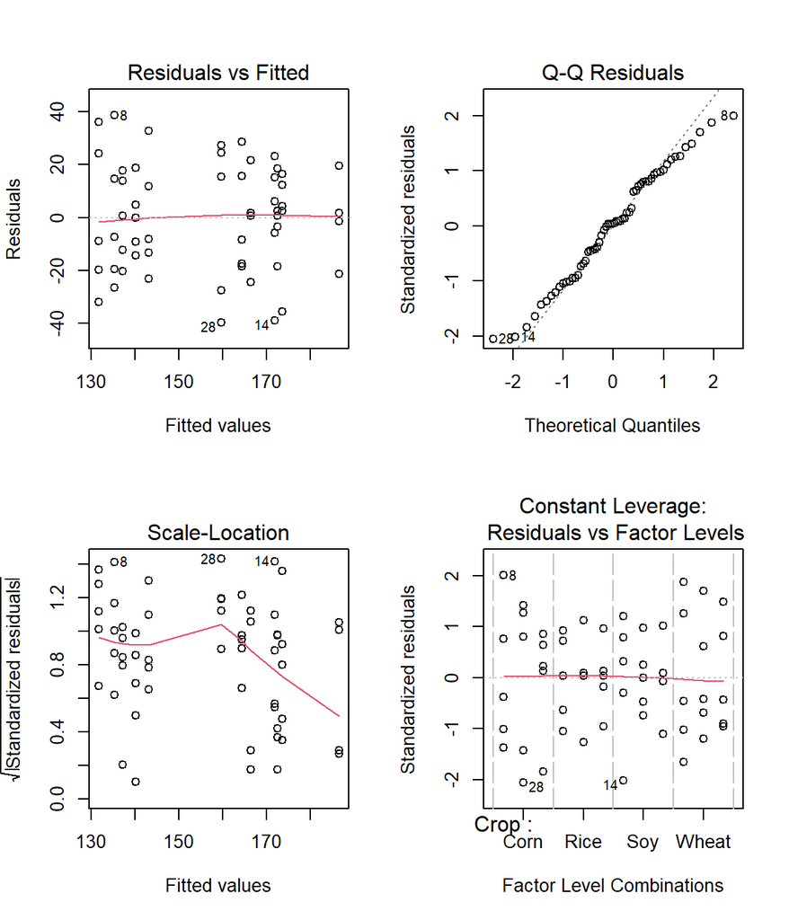

```r
par(mfrow = c(2,2))  # define the layout with 2x2 graphical panels
plot(crop.lm)
```

```r
summary(crop.lm)
```

```
| Call:
| lm(formula = Yield ~ Crop * Fertilizer, data = crop.data)
| Residuals:
|    Min     1Q Median     3Q    Max
| -39.60 -15.00   0.70  15.45  38.60
| Coefficients:
|                             Estimate Std. Error t value Pr(>|t|)
| (Intercept)                  135.400      9.639  14.048  < 2e-16 ***
| CropRice                       1.800     13.631   0.132  0.89549
| CropSoy                       36.400     13.631   2.670  0.01031 *
| CropWheat                     -3.600     13.631  -0.264  0.79283
| FertilizerBlend Y             24.200     13.631   1.775  0.08218 .
| FertilizerBlend Z             38.200     13.631   2.802  0.00729 **
| CropRice:FertilizerBlend Y     5.000     19.277   0.259  0.79646
| CropSoy:FertilizerBlend Y    -55.800     19.277  -2.895  0.00570 **
| CropWheat:FertilizerBlend Y  -12.800     19.277  -0.664  0.50987
| CropRice:FertilizerBlend Z    -3.000     19.277  -0.156  0.87698
| CropSoy:FertilizerBlend Z    -23.600     19.277  -1.224  0.22683
| CropWheat:FertilizerBlend Z   -5.600     19.277  -0.291  0.77269
| ---
| Signif. codes:  0 '***' 0.001 '**' 0.01 '*' 0.05 '.' 0.1 ' ' 1
| Residual standard error: 21.55 on 48 degrees of freedom
| Multiple R-squared:  0.4543,  Adjusted R-squared:  0.3292
| F-statistic: 3.632 on 11 and 48 DF,  p-value: 0.0008828
```

**Output Interpretations**

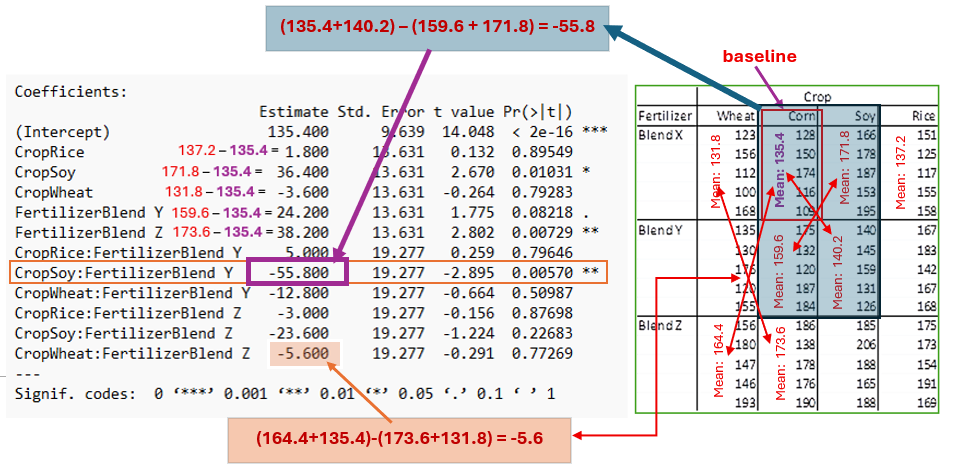

As we did with the one-way ANOVA, we can also extract the two-way ANOVA table directly from the linear regression model above.

```r
anova(crop.lm)
```

```
| Analysis of Variance Table
| Response: Yield
|                 Df  Sum Sq Mean Sq F value    Pr(>F)
| Crop             3  2965.7   988.6  2.1282 0.1089382
| Fertilizer       2  9702.2  4851.1 10.4436 0.0001716 ***
| Crop:Fertilizer  6  5892.6   982.1  2.1143 0.0687635 .
| Residuals       48 22296.4   464.5
| ---
| Signif. codes:  0 '***' 0.001 '**' 0.01 '*' 0.05 '.' 0.1 ' ' 1
```

The two-way ANOVA table provides three F-tests for assessing the two individual factors and their interaction effect, whereas the F-test in the regression output only tests whether all factors are jointly insignificant—a global goodness-of-fit measure. From this perspective, the two-way ANOVA F-tests offer more granular insights. However, regression coefficient inference allows for more detailed testing at individual factor levels, as well as for interaction effects between factor levels. Although Tukey’s HSD procedure provides confidence intervals (and family-wise tests for simultaneous comparisons), it does not explicitly account for interaction effects in the multiple comparisons.

```r
## fit an anova model since TukeyHSD() requires the aov() object
crop.aov <- aov(Yield ~ Crop * Fertilizer, data = crop.data)
## HSD calls
TukeyHSD(crop.aov)
```

```
|   Tukey multiple comparisons of means
|     95% family-wise confidence level
| Fit: aov(formula = Yield ~ Crop * Fertilizer, data = crop.data)
| $Crop
|                  diff       lwr       upr     p adj
| Rice-Corn    2.466667 -18.47792 23.411252 0.9891976
| Soy-Corn     9.933333 -11.01125 30.877918 0.5910428
| Wheat-Corn  -9.733333 -30.67792 11.211252 0.6069146
| Soy-Rice     7.466667 -13.47792 28.411252 0.7787573
| Wheat-Rice -12.200000 -33.14459  8.744585 0.4163283
| Wheat-Soy  -19.666667 -40.61125  1.277918 0.0728352
| $Fertilizer
|                  diff       lwr      upr     p adj
| Blend Y-Blend X  8.30 -8.183166 24.78317 0.4486138
| Blend Z-Blend X 30.15 13.666834 46.63317 0.0001620
| Blend Z-Blend Y 21.85  5.366834 38.33317 0.0066534
| $`Crop:Fertilizer`
|                              diff         lwr        upr     p adj
| Rice:Blend X-Corn:Blend X     1.8 -45.0050873  48.605087 1.0000000
| Soy:Blend X-Corn:Blend X     36.4 -10.4050873  83.205087 0.2718890
| Wheat:Blend X-Corn:Blend X   -3.6 -50.4050873  43.205087 1.0000000
| Corn:Blend Y-Corn:Blend X    24.2 -22.6050873  71.005087 0.8228174
| Rice:Blend Y-Corn:Blend X    31.0 -15.8050873  77.805087 0.5076482
| Soy:Blend Y-Corn:Blend X      4.8 -42.0050873  51.605087 0.9999999
| Wheat:Blend Y-Corn:Blend X    7.8 -39.0050873  54.605087 0.9999854
| Corn:Blend Z-Corn:Blend X    38.2  -8.6050873  85.005087 0.2115608
| Rice:Blend Z-Corn:Blend X    37.0  -9.8050873  83.805087 0.2506320
| Soy:Blend Z-Corn:Blend X     51.0   4.1949127  97.805087 0.0219849
| Wheat:Blend Z-Corn:Blend X   29.0 -17.8050873  75.805087 0.6066374
| Soy:Blend X-Rice:Blend X     34.6 -12.2050873  81.405087 0.3423125
| Wheat:Blend X-Rice:Blend X   -5.4 -52.2050873  41.405087 0.9999997
| Corn:Blend Y-Rice:Blend X    22.4 -24.4050873  69.205087 0.8838055
| Rice:Blend Y-Rice:Blend X    29.2 -17.6050873  76.005087 0.5967325
| Soy:Blend Y-Rice:Blend X      3.0 -43.8050873  49.805087 1.0000000
| Wheat:Blend Y-Rice:Blend X    6.0 -40.8050873  52.805087 0.9999990
| Corn:Blend Z-Rice:Blend X    36.4 -10.4050873  83.205087 0.2718890
| Rice:Blend Z-Rice:Blend X    35.2 -11.6050873  82.005087 0.3177646
| Soy:Blend Z-Rice:Blend X     49.2   2.3949127  96.005087 0.0315296
| Wheat:Blend Z-Rice:Blend X   27.2 -19.6050873  74.005087 0.6939901
| Wheat:Blend X-Soy:Blend X   -40.0 -86.8050873   6.805087 0.1614830
```

[output cut: 29 more lines]

```
| Wheat:Blend Y-Soy:Blend Y     3.0 -43.8050873  49.805087 1.0000000
| Corn:Blend Z-Soy:Blend Y     33.4 -13.4050873  80.205087 0.3943466
| Rice:Blend Z-Soy:Blend Y     32.2 -14.6050873  79.005087 0.4497486
| Soy:Blend Z-Soy:Blend Y      46.2  -0.6050873  93.005087 0.0559743
| Wheat:Blend Z-Soy:Blend Y    24.2 -22.6050873  71.005087 0.8228174
| Corn:Blend Z-Wheat:Blend Y   30.4 -16.4050873  77.205087 0.5372002
| Rice:Blend Z-Wheat:Blend Y   29.2 -17.6050873  76.005087 0.5967325
| Soy:Blend Z-Wheat:Blend Y    43.2  -3.6050873  90.005087 0.0956612
| Wheat:Blend Z-Wheat:Blend Y  21.2 -25.6050873  68.005087 0.9163288
| Rice:Blend Z-Corn:Blend Z    -1.2 -48.0050873  45.605087 1.0000000
| Soy:Blend Z-Corn:Blend Z     12.8 -34.0050873  59.605087 0.9982727
| Wheat:Blend Z-Corn:Blend Z   -9.2 -56.0050873  37.605087 0.9999234
| Soy:Blend Z-Rice:Blend Z     14.0 -32.8050873  60.805087 0.9962200
| Wheat:Blend Z-Rice:Blend Z   -8.0 -54.8050873  38.805087 0.9999811
| Wheat:Blend Z-Soy:Blend Z   -22.0 -68.8050873  24.805087 0.8953849
```

The following annotated output illustrates how to calculate various differences in the results of Tukey’s HSD procedure.

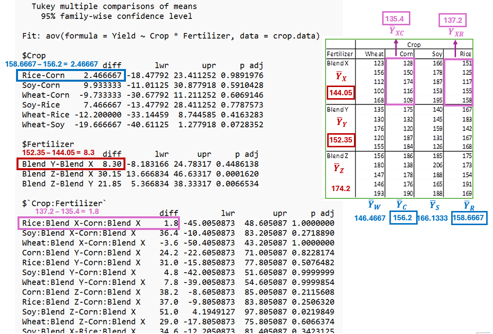

The following YouTube video (28 minutes) is one of the very few that uses a linear regression approach to perform ANOVA analysis (https://www.youtube.com/watch?v=CS5ogBL-MHo). Please pay close attention to the explanation of the linear regression output, particularly the explanation of the two-way ANOVA with interaction term.

Finally, practice two-way ANOVA using regression approaches based on the following data table with two binary factors. Because both factors are binary, the interpretation of the output should be straightforward.

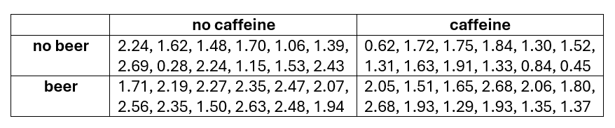